# Does it work? Performance on the exam

Florian Sense

July 2018 – last compiled: 2018-07-05 13:01:08

# Goal

We want to get a global overview of whether (1) studying with the system improves performance on (a) the exam as a whole and (b) individual exam questions that were studied or not. Additionally, we’d like to know whether (2) usage statistics and model estimates can predict performance (for both (a) and (b) again).

```r
library(BayesFactor)
library(ggplot2)
theme_set(theme_minimal())
# For regression models:
library(lme4)
inv.logit <- function(x) exp(x)/(1+exp(x)) # To convert glmer output
load(file.path("..", "data", "data & grades anon w IC.Rdata"))
figures.folder <- "figures for ICCM poster"
```

# Does studying with the system improve exam performance?

## Final grade on the exam

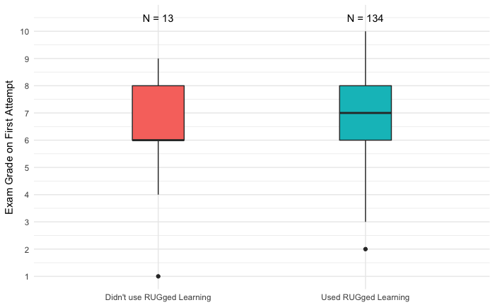

```r
grades$usedRL <- ifelse(grades$User %in% data$User, "Used RUGged Learning", "Didn't use RUGged Learning")
bf.alt <- round( as.vector(ttestBF(formula=Grade ~ usedRL, data=grades)) , 2)
grand.means <- aggregate(Grade ~ usedRL, grades, mean) # Globally
Ns <- data.frame(N = table(grades$usedRL), median = aggregate(Grade ~ usedRL, grades, median)$Grade)
ggplot(grades, aes(x=usedRL, y=Grade)) +
  # geom_violin(scale="count", draw_quantiles = c(.25, .5, .75)) +
  geom_boxplot(width=.25, aes(fill=usedRL), show.legend = FALSE) +
  annotate("text", x=1:2, y=10.5, label=paste("N =", Ns$N.Freq)) + scale_y_continuous(breaks=1:10) +
  labs(x=NULL, y="Exam Grade on First Attempt") +
  NULL
```

Note that these distributions are quite imbalanced: Only 13 of the students that gave informed consent did not use the system at all (8.8%). The mean grade for those students is 6.23 compared with a mean grade of 7.1 for the 134 students that did use the system. Given the small sample size for one of the groups, this overall difference should be interpreted with caution, though.

## Individual items on the exam

To gain a bit more insight, we can zoom in on the individual exam questions. The vast majority of the students did you use the system, which makes the comparison above extremely imbalanced. Even the people that did use RL, however, did not (necessarily) see *all* the items. This allows us to split, even within a person, the performance on the exam between those that did see the items and those that did not. So what I’ll do is compute the proportion correct on the exam separately for each student: one for the items that they did study (if any) and one for the items they did not study.

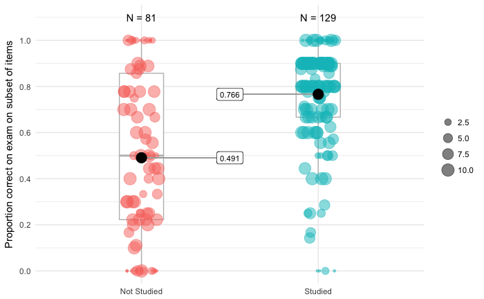

The size of the points indicates the number of observations the proportion is based on, smaller points correspond to fewer observations.

The main conclusion here is thae the proportion is much higher for the items that were studied.

One quick check we might want to do is plot the same but only for proportions that are based on at least `x` values:

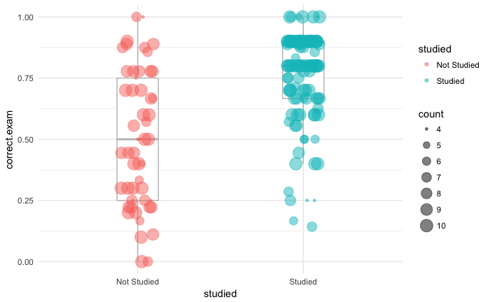

Setting `x` to 1, 2, or 3 (or even 4) doesn’t change the overall pattern at all. This suggests that the results we see above are not simply due to extreme values at 0 or 1 driven by single items (i.e, a student that has only studied one item that appeared on the exam and got one correct/incorrect)

# Are usage statistics and model estimates related to exam performance?

## Individual items on the exam